# Two-band spectral indices

Jose Eduardo Meireles

July 2026

A large family of vegetation and mineral indices are just a **normalized difference between two bands**: `(R[band1] - R[band2]) / (R[band1] + R[band2])`. NDVI and PRI are two well-known examples, but the formula itself doesn’t care which bands you plug in. Rather than exporting a growing list of one-off named functions, `spectrolab` exports a single *factory*, `make_spectral_index()`, and ships two ready-made indices built with it, reachable through the `spectral_index` list.

```r
library(spectrolab)
spec = as_spectra(spec_matrix_example, name_idx = 1)
```

## The built-in indices

```r
names(spectral_index)
```

```
#> [1] "ndvi" "pri"
```

```r
# Call an entry directly on a spectra object
head(spectral_index$ndvi(spec))
```

```
#>  species_7  species_8  species_5  species_7 species_10  species_1
#>  0.7957208  0.7902180  0.7938715  0.7951724  0.7955650  0.7948332
```

```r
head(spectral_index$pri(spec))
```

```
#>  species_7  species_8  species_5  species_7 species_10  species_1
#> 0.03608121 0.03997600 0.05116001 0.03133087 0.03532950 0.03818682
```

- `spectral_index$ndvi` – Normalized Difference Vegetation Index, `(R800 - R680) / (R800 + R680)`
- `spectral_index$pri` – Photochemical Reflectance Index, `(R570 - R531) / (R570 + R531)`

Both return a named numeric vector, one value per sample (names come from `names(x)`), not a `spectra` object – an index is a per-sample summary statistic, not a spectrum.

To compute several at once and get a tidy data.frame back, use `spectral_indices()`:

```r
idx = spectral_indices(spec)   # defaults to all of names(spectral_index)
head(idx)
```

```
#>   sample_name      ndvi        pri
#> 1   species_7 0.7957208 0.03608121
#> 2   species_8 0.7902180 0.03997600
#> 3   species_5 0.7938715 0.05116001
#> 4   species_7 0.7951724 0.03133087
#> 5  species_10 0.7955650 0.03532950
#> 6   species_1 0.7948332 0.03818682
```

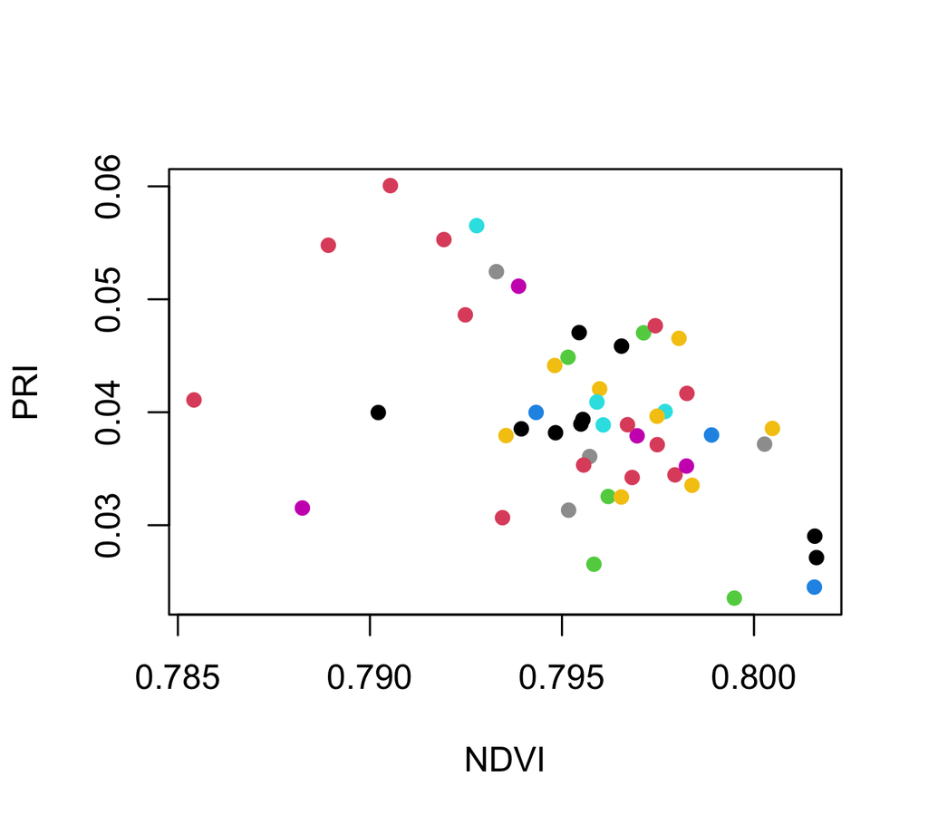

```r
plot(idx$ndvi, idx$pri, xlab = "NDVI", ylab = "PRI", pch = 16,
     col = as.factor(names(spec)))
```

## Building your own index

`make_spectral_index(band1, band2, tolerance = 1)` returns a function of `(x, tolerance)` – exactly how `spectral_index$ndvi` and `spectral_index$pri` themselves are defined. Use it directly for a custom two-band index, without adding a new name to the package’s namespace:

```r
# A water-band index, e.g. R970 vs a reference band at R900
wbi = make_spectral_index(970, 900)
head(wbi(spec))
```

```
#>   species_7   species_8   species_5   species_7  species_10   species_1
#> -0.01744116 -0.01642318 -0.01798847 -0.01696158 -0.01693342 -0.01908124
```

If you use a custom index often, keep the function around (or add it to your own named list, mirroring `spectral_index`) rather than recomputing `make_spectral_index()` on every call – it’s cheap either way, but a descriptive variable name documents intent.

## Gotchas

- **Bands must be strictly increasing.** Like the other transform functions, indices error on raw, unspliced data – run `match_sensors()` first (see the Matching sensor overlap vignette).
- **“Nearest band within tolerance”, not “exact band”.** Your data’s bands rarely land exactly on 800.000 or 680.000; `spectral_index` functions find the *nearest available band* to the requested wavelength and use it, erroring only if nothing is within `tolerance` (default 1, in the same units as your bands – usually nm). On coarse-resolution data this means the band actually used could be a few tenths of a nm away from what you asked for; widen `tolerance` deliberately if your data’s resolution requires it, rather than being surprised by an error.

```r
# spec is at 1nm resolution. Asking for an off-grid band (970.5) with
# tolerance = 0 fails rather than silently snapping to the nearest one...
off_grid = make_spectral_index(970.5, 900)
off_grid(spec, tolerance = 0)
```

```
#> Error in `i_nearest_band_idx()`:
#> ! No band found within 0 (units) of 970.5. Nearest available band is 970.
```

```r
# ...while the default tolerance (1) is enough to snap to band 970 and succeed
head(off_grid(spec))
```

```
#>   species_7   species_8   species_5   species_7  species_10   species_1
#> -0.01744116 -0.01642318 -0.01798847 -0.01696158 -0.01693342 -0.01908124
```

- **The band wavelengths are captured when you call `make_spectral_index()`, not re-evaluated later.** `wbi = make_spectral_index(970, 900)` always compares bands 970 and 900, even if you later change what `970` or `900` mean in your analysis – there’s no lazy/symbolic re-binding. Call `make_spectral_index()` again if you need different bands.
- **An index is a summary, not a spectrum.** The output has one value per *sample*, not one value per *band* – don’t expect `plot()` (which expects a `spectra` object) to work on it.